# 14. APIs and JSON

# JSON

## Format

JSON (JavaScript Object Notation) is a popular format for storing data. While, as its name suggests, it was designed for use in a particular programming language (JavaScript), methods for importing JSON are available in almost all programming languages, including R. Because of the importance of JavaScript in web development, JSON is a particularly popular format for providing data that is either provided by a web interface or is designed to be displayed through a browser-based visualization.

There would be no need for an entire chapter on the process of JSON files if it was just an alternative data format that could be read into R with an appropriate package. Unfortunately, there is often more work required in order to work with JSON data. First, unlike CSV files, data stored in a JSON format may not (and often is not) be rectangular. This requires understanding the internal structures used to store JSON data and learning how to use R to turn these structures into tables. This is not something that can automated because there are often different approaches depending on the meaning of the data and underlying research questions. Secondly, data provided in JSON format is often given through a web-based API. Typically this requires requesting small chunks of a dataset and writing code to put them together. In this chapter we will cover both of these complications by drawing on the base R and string manipulation skills covered in the previous chapters.

As a starting place, it is useful to see an example of a typical JSON file. Here is a small file that contains information about an Apple, such as some nutritional information, common colors, cultivars, and a set of mythical people who have been traditionally associated with apples.

```
{
    "item": "Apple",
    "liked_by": ["Adam", "Eve", "Heracles"],
    "nutrition": {
        "vitamin_a": 1,
        "vitamin_c": 8,
        "iron": 0.26
    },
    "colors": ["red", "yellow", "green"],
    "cultivars": [
        {
            "name": "Fuji",
            "source": "Japan"
        },
        {
            "name": "Gala",
            "source": "New Zealand"
        },
        {
            "name": "Cripps Pink",
            "source": "Australia"
        }
    ]
}
```

- scalar values: a number, a string, true, false, or null
- ordered array
- a set of name-value pairs

Ordered arrays are contained in square brackets and sets of name value pairs are stored inside of curly braces. The names are contained in double quotes, followed by a colon. All other strings are also contained in quotes. The arrays and sets can themseleves contain scalar values, ordered arrays, and name-valued pairs. In this way, JSON data can contain a limitless set of heirarchical relationships.

Notice that the JSON file described above is organized with nice spacing in order to see the heirarchical structure of the file. However, this does not effect the way data are interpretted within the file. Often, for space reasons, all of the organizing whitespace is ignored and a JSON file is stored in a *minified* format. For example, the following:

```
## {"item":"Apple","liked_by":["Adam","Eve","Heracles"],"nutrition":
## {"vitamin_a":1,"vitamin_c":8,"iron":0.26},"colors":
## ["red","yellow","green"],"cultivars":
## [{"name":"Fuji","source":"Japan"},{"name":"Gala","source":"New
## Zealand"},{"name":"Cripps Pink","source":"Australia"}]}
```

Would be parsed exactly the same as the more aesthetically pleasing format shown above.

## Reading JSON

Reading a JSON file into R is relatively easy using the functions provided by the **jsonlite** package. Assuming we have a file “apple.json” in our data directory, the package’s function `read_json` can be used to read in the file without an additional setup.

```r
library(jsonlite)

obj <- read_json(file.path("data", "apple.json"))
```

However, because there is not clear way to create a rectangular dataset from the JSON file, the package has loaded the JSON data into an R list object.

```r
class(obj)
```

```
## [1] "list"
```

This list, in turn, contains elements that contain sublists, that can then contain their own sublists. In general, a set of name-value pairs are stored as named lists and ordered arrays are stored as unnamed lists. Scalar values are the only objects that can be unambiguously stored as an R vector (of length 1).

In order to get access to the internal data in the JSON file from within R, we need to successively drill down into the various sublists. The easiest way to do this is to first call the names function to see the names of the name-value pairs.

```r
names(obj)
```

```
## [1] "item"      "liked_by"  "nutrition" "colors"    "cultivars"
```

The item record is a scalar value. Using the dollar sign operator allows for access to the item name of the record as an R vector.

```r
obj$item
```

```
## [1] "Apple"
```

Selecting the nutrition element, on the other hand, returns another named list because it is another set of name-value pairs in the JSON file.

```r
obj$nutrition
```

```
## $vitamin_a
## [1] 1
##
## $vitamin_c
## [1] 8
##
## $iron
## [1] 0.26
```

Grabing the `liked_by` element also gives a list object, but this time without names because it corresponds to an array of ordered values.

```r
obj$liked_by
```

```
## [[1]]
## [1] "Adam"
##
## [[2]]
## [1] "Eve"
##
## [[3]]
## [1] "Heracles"
```

In the next section we will see a way of creating tabular datasets from the data given in the JSON records.

## Creating Tabular Data

The data from “apple.json” cannot be easily stored in a single rectangular data format, however it is possible to create three datasets that contain all of the records. These are: (1) a one-row dataset of the nutritional values, (2) a dataset with one row for each person associated as liking apples, and (3) a dataset with one row for each cultivar.

In order to create these tables, we will use several R functions. Functions `as.numeric` and `as.character` will take a list of elements and unravel them into the respective type. For example, we can create a vector of the people in the “liked by” array as follows:

```r
as.character(obj$liked_by)
```

```
## [1] "Adam"     "Eve"      "Heracles"
```

In order to put individual vectors into a dataset, we will use the function `tibble`. We provide the names of the columns, followed by an equals sign, and the vector containing the data. Generally, you will want to either put all vectors of the same lengths into a call to `tibble` or pass length 1 vectors that are repeated for every row. For example, here is nutrional value table:

```r
tibble(
  item = obj$item,
  vitamin_a = obj$nutrition$vitamin_a,
  vitamin_c = obj$nutrition$vitamin_c,
  iron = obj$nutrition$iron
)
```

```
## # A tibble: 1 × 4
##   item  vitamin_a vitamin_c  iron
##   <chr>     <int>     <int> <dbl>
## 1 Apple         1         8  0.26
```

The nutritional values are already scalar values so there is no need to use the `as.numeric` function here. Alternatively, as an illustration of how there are multiple ways to turn a JSON dataset into a table, we could have stored this data in a long format with one row for each nutritional value. This requires unraveling the list of name-value pairs with `as.nuermci` and using the `names` function to get the names of the nutrients. However, it is also somewhat simplier because we do not need to manually specify each of the nutrients individually.

```r
tibble(
  item = obj$item,
  element = names(obj$nutrition),
  value = as.numeric(obj$nutrition)
)
```

```
## # A tibble: 3 × 3
##   item  element   value
##   <chr> <chr>     <dbl>
## 1 Apple vitamin_a  1
## 2 Apple vitamin_c  8
## 3 Apple iron       0.26
```

For the “liked by” table, we need a similar kind of unravelling:

```r
tibble(
  item = obj$item,
  liked_by = as.character(obj$liked_by)
)
```

```
## # A tibble: 3 × 2
##   item  liked_by
##   <chr> <chr>
## 1 Apple Adam
## 2 Apple Eve
## 3 Apple Heracles
```

Unlike the nutrional data, there is no obvious way to store this in a wider format.

The cultivars dataset is slightly more complicated because within each cultivar we need to grab the name and the source location of the cultivar. To do this, we can use `lapply` along with the function `getElement`. Here are the names, for example:

```r
as.character(lapply(obj$cultivars, getElement, "name"))
```

```
## [1] "Fuji"        "Gala"        "Cripps Pink"
```

Putting this all together, we can put together the full cultivars dataset.

```r
tibble(
  item = obj$item,
  cultivar = as.character(lapply(obj$cultivars, getElement, "name")),
  source = as.character(lapply(obj$cultivars, getElement, "source"))
)
```

```
## # A tibble: 3 × 3
##   item  cultivar    source
##   <chr> <chr>       <chr>
## 1 Apple Fuji        Japan
## 2 Apple Gala        New Zealand
## 3 Apple Cripps Pink Australia
```

The `getElement` function is often a very useful tool for pulling apart data read from a tree-like JSON data structure while turning it into a tabular dataset.

## Fetching JSON Data through an API

As a quick test, open the [DuckDuckGo](https://duckduckgo.com/) search homepage and search for a phrase. Then, on the search results page, take a look at the URL of the page. If you search for the term “data science”, you should see something like this:

- https://duckduckgo.com/?q=data+science&t=h_&ia=web

This is an example of a URL containing a query string. The part after the question mark symbol is a way of defining input variables. These variables are, typically seperated by amperstands. This query specifies three variables: “q”, “t”, and “ia”. The important variable for us is the variable “q” (the search query), which contains the terms that were being for.

When most people use the internet, search query strings are constantly being created automatically to pass data between webpages and indicate what kinds of content should be served through the a browser. Typically, we don’t think too much (or at all) about these variables and what they mean because we do not directly interact with them.

A Web API is a way of requesting structured data through the use of a URL query string. Unlike the example of the automatically created query string from DuckDuckGo, when requesting data from a Web API the query string must be constructed intentionally. Usually there will be extensive documentation about what variables are available to specify, what options are allowed, along with a description of the output format. Most commonly, these APIs return data in a JSON format, though they can in theory return data in any format they choose.

In this section we are going to grab data from the Wikipedia API. For a complete documentation of their extensive API see [MediaWiki API documentation page](https://en.wikipedia.org/w/api.php). Our goal here is to get page view statistics from the “apple” page over the past 60 days. To do this, we need to set the following query parameters:

- **action**: Describes the kind of action we want to perform. Here we want to “query” the data rather than trying to change any of the available data.
- **format**: Gives the output format of the dataset, which we set to “json”. Other options include “xml” and “php”, but JSON data is the prefered method.
- **prop**: Are the properties that we are requesting for a given page. In this case we are asking for “pageviews”.
- **titles**: A list of pages we are requesting data for. There can be up to 50 of these, seperated by pipes (`|`), but here we are requesting only a single page for “apple”.

To create a query string with these parameters, we can use the `stri_paste` function. This will make it easier in the next section to modify the code to search for other pages.

```r
base_url <- "https://en.wikipedia.org/w/api.php"
options <- "?action=query&format=json&prop=pageviews&titles="
url <- stri_paste(base_url, options, "apple")
url
```

```
## [1] "https://en.wikipedia.org/w/api.php?action=query&format=json&prop=pageviews&titles=apple"
```

In order to request this data through the media wiki API, we will use the `read_lines` function. Typically JSON data is sent without an extra “newline” character at the end in order to save space.

```r
json_text <- read_lines(url)
json_text
```

[output not shown]

The result is a string containing JSON data. We can parse this using `parse_json` and start looking through its contents.

```r
obj <- parse_json(json_text)
names(obj)
```

[output not shown]

The actual interesting data is buried a bit inside several layers of data structures. Specifically, we need to look inside the “query” value, then inside of the pages value. As we only requested one page, we can select the first page, and then grab the values for the “pageviews” key. Here are the first 3 values from the page views:

```r
obj$query$pages[[1]]$pageviews[c(1, 2, 3)]
```

[output not shown]

This should look similar to the nutrition data we had in our example page. To grab the data we need to call `as.numeric` to access to the counts and `names` to accees the dates.

```r
page_views <- tibble(
  item = "apple",
  date = names(obj$query$pages[[1]]$pageviews),
  views = as.numeric(unlist(obj$query$pages[[1]]$pageviews)),
)
page_views
```

[output not shown]

This dataset already looks like a format that we can work with using the skills covered in the core chapters of this text. A little more work using the methods from Chapter 11 could be used to turn the date variable into a date-type object, but the work of requesting data from API and parsing apart the JSON data is complete.

## Creating a Larger Dataset

To finish, we will put together the process used in the previous section to build a pageview dataset for all of the pages, in our `foods` dataset. The dataset already contains the proper names to describe the Wikipedia pages for each food item. These mostly match the names of the foods. There are some differences, such as indicators that we want the “turkey” page for the bird and not the country.

```r
all_items <- food$wiki
all_items
```

```
##  [1] "apple"               "asparagus"           "avocado"
##  [4] "banana"              "chickpea"            "green_bean"
##  [7] "beef"                "bell_pepper"         "callinectes_sapidus"
## [10] "broccoli"            "cabbage"             "cantaloupe"
## [13] "carrot"              "catfish"             "cauliflower"
## [16] "celery"              "cheese"              "chicken"
## [19] "clam"                "cod"                 "maize"
## [22] "cucumber"            "duck"                "flounder"
## [25] "grapefruit"          "grape"               "halibut"
## [28] "haddock"             "kiwifruit"           "sheep"
## [31] "lemon"               "lettuce"             "lime_(fruit)"
## [34] "lobster"             "milk"                "mushroom"
## [37] "oat"                 "onion"               "orange_(fruit)"
## [40] "oyster"              "peach"               "pear"
## [43] "penne"               "pineapple"           "plum"
## [46] "pork"                "quinoa"              "brown_rice"
## [49] "salmon"              "scallop"             "shrimp"
## [52] "sour_cream"          "strawberry"          "sweet_potato"
## [55] "swordfish"           "tangerine"           "tomato"
## [58] "tuna"                "turkey_(bird)"       "potato"
## [61] "yogurt"
```

Everytime that we request data from the MediaWiki API it puts a small strain on the Wikipedia servers. It also takes a bit of time to send the request to their servers, wait for the response, and then load the results. For larger datasets it would be a bad idea to make a new request every time we want another field from our collection of data. A good practice is to split this process into two parts: first we download the JSON files and save them locally, then we read the local files and process them as needed.

The function `sm_check_download` can be used to check if a file exists locally, and download the file otherwise. It has arguments: `src` for the location of the URL and `dest` for the local location where the file is found. Here, we will use this function to store all of the json pageview files for our dataset in a directory called “pageview_cache”.

```r
for (item in all_items)
{
  src_url <- paste0(base_url, options, item)
  dest_path <- file.path("pageview_cache", paste0(item, ".json"))

  sm_check_download(src = src_url, dest = dest_path)
}
```

With the pages downloaded, we now repeat the process in the previous section for each of the pages in our dataset using a for loop. The individual page view tables are combined using `bind_rows` into a larger table `page_views_all` containing all of the data

```r
page_views_all <- NULL
for (item in all_items)
{
  dest_path <- file.path("pageview_cache", paste0(item, ".json"))
  obj <- read_json(dest_path)

    views <- unlist(obj$query$pages[[1]]$pageviews)
  page_views <- tibble(
    item = item,
    date = names(views),
    views = as.numeric(views),
  )
  page_views_all <- bind_rows(page_views_all, page_views)
}
```

Looking at the data, we see that there are now 60 rows for each of the items in the `foods` data.

```r
page_views_all
```

```
## # A tibble: 3,660 × 3
##    item  date       views
##    <chr> <chr>      <dbl>
##  1 apple 2021-06-13  2361
##  2 apple 2021-06-14  2615
##  3 apple 2021-06-15  2575
##  4 apple 2021-06-16  2416
##  5 apple 2021-06-17  2536
##  6 apple 2021-06-18  2446
##  7 apple 2021-06-19  2168
##  8 apple 2021-06-20  2237
##  9 apple 2021-06-21  2660
## 10 apple 2021-06-22  2495
## # … with 3,650 more rows
```

We can now use this dataset to start exploring the page view dataset. As an interesting starting point, we can compute the minimum and maximum page views over the last two months for each page, and label the 10 pages that have had the highest number of maximum page views.

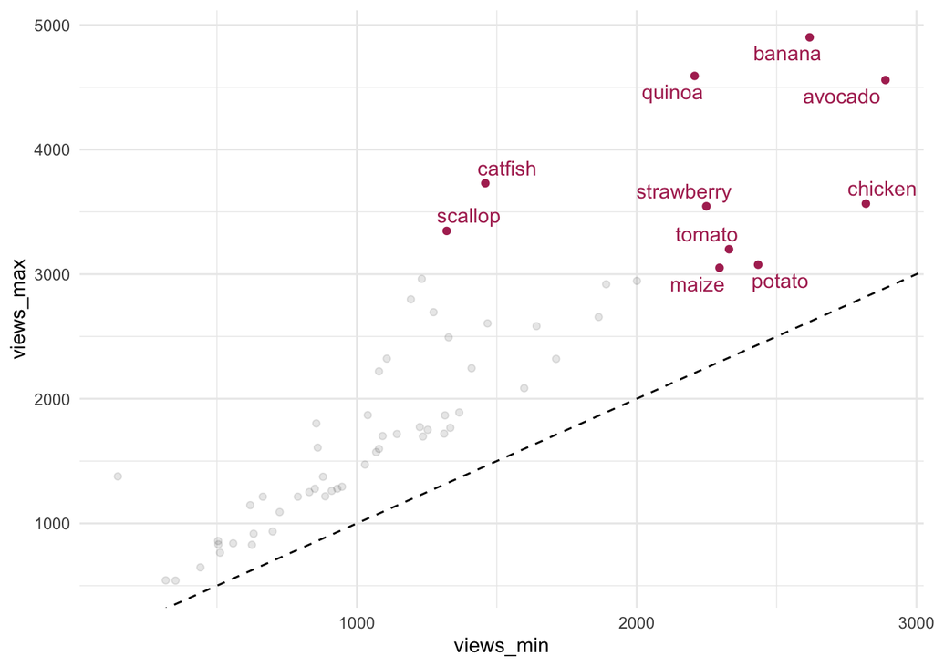

```r
df <- page_views_all %>%
  group_by(item) %>%
  summarize(sm_min(views), sm_max(views))

df %>%
  arrange(desc(views_max)) %>%
  slice(1:10) %>%
  ggplot(aes(views_min, views_max)) +
    geom_point(data = df, alpha = 0.1) +
    geom_point(color = "maroon") +
    geom_text_repel(aes(label = item), color = "maroon") +
    geom_abline(slope = 1, intercept = 0, linetype = "dashed")
```

Several additional applications using the page views dataset are shown in Chapter 11. Now, having following along with the notes here, it should now be clear how the data were constructed using the MediaWiki API.